← Voltar ao Portal

[figure not shown]

Visão Geral

# Síntese Avaliativa do Desempenho dos Programas do PPA Bahia 2024–2027 Ano 2025

# **1 - Desempenho Global dos Programas**

Este documento apresenta uma Síntese Avaliativa do Desempenho dos Programas do Plano Plurianual - PPA 2024- 2027, trazendo uma visão estratégica dos seus resultados, de forma sintética, transparente e colaborativa. São levados em consideração o Indicador Sintético de Desempenho do Programa (ISDP), a evolução dos Indicadores de Programa, a eficácia das metas dos Indicadores de Compromisso, o desempenho da execução orçamentária-financeira e da execução física das Ações orçamentárias. O ISDP é uma síntese dessas quatro dimensões, destacando o desempenho do programa em relação aos resultados obtidos e aos esforços despendidos.  
Dos 47 programas avaliados, três alcançaram desempenho ótimo, 16 tiveram bons desempenhos, 19 apresentaram desempenhos regulares, seis tiveram desempenho baixo e três registraram desempenhos muito baixos. Dos 154 indicadores de programa, 55,2% apresentaram evolução positiva, 33,1% apresentaram evolução negativa, 3,2% apresentaram evolução constante e 8,4% foram considerados não aptos para avaliação. Dos 575 Indicadores de Compromisso, 11,5% tiveram desempenho muito baixo, 4,2% tiveram desempenho baixo, 8,9% tiveram desempenho regular, 10,1% tiveram bom desempenho, 36,8% tiveram ótimo desempenho, 23,8% ficaram com desempenho indeterminado e 5,9% foram considerados não aptos para avaliação.  
Adicionalmente, são apresentados os principais resultados alcançados, evidenciando os avanços e conformidades dos cinco programas com melhores resultados, além das oportunidades de melhoria dos cinco, com menores resultados. Enquanto neste documento a análise abrange os programas e seus componentes de maneira sintética, nos demais relatórios, a análise detalhada evidencia o comportamento dos componentes do PPA por programas e por órgãos (https://www.ba.gov.br/seplan/monitoramento-e-avaliacao/avaliacao-do-ppa). Além desta Síntese, o [Painel BI - Boletim de Avanços e Oportunidades de Melhoria](https://app.powerbi.com/view?r=eyJrIjoiN2Q0ODliNDItZDFjZi00MGM1LTliNGEtODVmZDAwZTQ1OGEyIiwidCI6IjRjZDgzNWY0LTU0NDAtNDA4Zi05M2EzLTk3NWZjMTdjMzg0YSIsImMiOjR9) oferece informações organizadas em uma perspectiva estratégica do desempenho consolidado dos programas, detalhando, no entanto, cada componente avaliado. A análise nesta seção engloba os programas e seus componentes conforme segue:

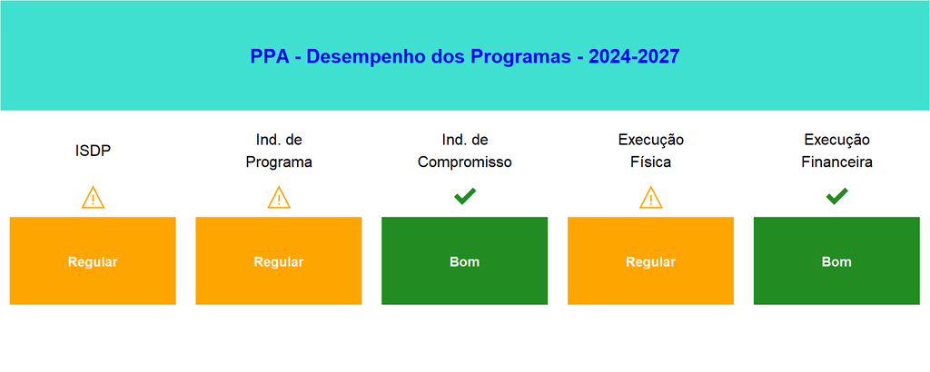

# **2 - Avanços e Conformidades dos Programas**

**✔** O programa 426 - Bahia Antirracista obteve a classificação de ótimos tanto em seus indicadores de programa quanto em seus indicadores de compromisso. A execução física também foi avaliada como ótima, enquanto a execução orçamentário-financeira foi classificada como boa.

**✔** O programa 413 - Bahia Solidária e Artesanal teve seus indicadores de programa avaliados como ótimos, enquanto os indicadores de compromisso receberam a classificação de bom. A execução física e a execução orçamentário-financeira deste programa também foram classificadas como boas.

**✔** O programa 401 - Educação e Cultura em Direitos Humanos apresenta indicadores de programa classificados como ótimos, com indicadores de compromisso avaliados como regulares. A execução física também é considerada ótima, assim como a execução orçamentário-financeira.

**✔** O programa 406 - Cultura em Toda a Bahia apresenta indicadores de programa e de compromisso avaliados como ótimos, mas a execução física e a execução orçamentário-financeira são consideradas regulares.

**✔** O programa 402 - SUAS Bahia: Fortalecendo a Assistência Social se destaca com indicadores de programa e de compromisso avaliados como ótimos. No entanto, a execução física é classificada como regular, enquanto a execução orçamentário-financeira mantém a avaliação ótima.

# **3 - Oportunidade de Melhoria dos Programas**

**⚠** O programa “Minha Terra Legal: Acesso à Terra e Garantia de Direitos no Campo” (415) apresenta indicadores de programa classificados como muito baixos, assim como os indicadores de compromisso e a execução física, que também receberam notas muito baixas. Por outro lado, a execução orçamentário-financeira foi avaliada como boa.

**⚠** O programa “Bahia Minha Casa” (418), os indicadores de programa e de compromisso são considerados muito baixos, enquanto a execução física e orçamentário-financeira foram classificadas como baixas.

**⚠** O programa “Segurança Hídrica” (434) apresenta uma situação semelhante, com indicadores de programa muito baixos, indicadores de compromisso regulares e tanto a execução física quanto a execução orçamentário-financeira avaliadas como baixas.

**⚠** No programa “404 - Cuidado em Liberdade: Reduzindo Danos”, os indicadores de programa são considerados muito baixos, enquanto os indicadores de compromisso são avaliados como regulares. A execução física destaca-se com uma avaliação ótima, e a execução orçamentário-financeira é classificada como boa.

**⚠** O programa “Gente Boa no Trânsito” apresenta indicadores de desempenho variados, com uma classificação de “Muito Baixo” para os indicadores de programa, “Regular” para os indicadores de compromisso, “Ótimo” na execução física e “Bom” na execução orçamentário-financeira.

Desenvolvido por: DAP – Diretoria de Avaliação de Políticas Públicas